# Red Wine Quality study by VARADHARAJAN THIAGARAJAN

```
## [1] "C:/Users/varadharajan/Desktop/UDACITY_Assignments/term2/Red_Wine_Quality_Analysis_Assignment"
```

```
## [1] 1599   13
```

```
## 'data.frame':    1599 obs. of  15 variables:
##  $ X                   : int  1 2 3 4 5 6 7 8 9 10 ...
##  $ fixed.acidity       : num  7.4 7.8 7.8 11.2 7.4 7.4 7.9 7.3 7.8 7.5 ...
##  $ volatile.acidity    : num  0.7 0.88 0.76 0.28 0.7 0.66 0.6 0.65 0.58 0.5 ...
##  $ citric.acid         : num  0 0 0.04 0.56 0 0 0.06 0 0.02 0.36 ...
##  $ residual.sugar      : num  1.9 2.6 2.3 1.9 1.9 1.8 1.6 1.2 2 6.1 ...
##  $ chlorides           : num  0.076 0.098 0.092 0.075 0.076 0.075 0.069 0.065 0.073 0.071 ...
##  $ free.sulfur.dioxide : num  11 25 15 17 11 13 15 15 9 17 ...
##  $ total.sulfur.dioxide: num  34 67 54 60 34 40 59 21 18 102 ...
##  $ density             : num  0.998 0.997 0.997 0.998 0.998 ...
##  $ pH                  : num  3.51 3.2 3.26 3.16 3.51 3.51 3.3 3.39 3.36 3.35 ...
##  $ sulphates           : num  0.56 0.68 0.65 0.58 0.56 0.56 0.46 0.47 0.57 0.8 ...
##  $ alcohol             : num  9.4 9.8 9.8 9.8 9.4 9.4 9.4 10 9.5 10.5 ...
##  $ quality             : int  5 5 5 6 5 5 5 7 7 5 ...
##  $ quality_category    : Ord.factor w/ 3 levels "Low"<"Medium"<..: 2 2 2 2 2 2 2 3 3 2 ...
##  $ alcohol_category    : Ord.factor w/ 2 levels "Alcohol Low"<..: 1 1 1 1 1 1 1 1 1 1 ...
```

```
##        X          fixed.acidity   volatile.acidity  citric.acid
##  Min.   :   1.0   Min.   : 4.60   Min.   :0.1200   Min.   :0.000
##  1st Qu.: 400.5   1st Qu.: 7.10   1st Qu.:0.3900   1st Qu.:0.090
##  Median : 800.0   Median : 7.90   Median :0.5200   Median :0.260
##  Mean   : 800.0   Mean   : 8.32   Mean   :0.5278   Mean   :0.271
##  3rd Qu.:1199.5   3rd Qu.: 9.20   3rd Qu.:0.6400   3rd Qu.:0.420
##  Max.   :1599.0   Max.   :15.90   Max.   :1.5800   Max.   :1.000
##  residual.sugar     chlorides       free.sulfur.dioxide
##  Min.   : 0.900   Min.   :0.01200   Min.   : 1.00
##  1st Qu.: 1.900   1st Qu.:0.07000   1st Qu.: 7.00
##  Median : 2.200   Median :0.07900   Median :14.00
##  Mean   : 2.539   Mean   :0.08747   Mean   :15.87
##  3rd Qu.: 2.600   3rd Qu.:0.09000   3rd Qu.:21.00
##  Max.   :15.500   Max.   :0.61100   Max.   :72.00
##  total.sulfur.dioxide    density             pH          sulphates
##  Min.   :  6.00       Min.   :0.9901   Min.   :2.740   Min.   :0.3300
##  1st Qu.: 22.00       1st Qu.:0.9956   1st Qu.:3.210   1st Qu.:0.5500
##  Median : 38.00       Median :0.9968   Median :3.310   Median :0.6200
##  Mean   : 46.47       Mean   :0.9967   Mean   :3.311   Mean   :0.6581
##  3rd Qu.: 62.00       3rd Qu.:0.9978   3rd Qu.:3.400   3rd Qu.:0.7300
##  Max.   :289.00       Max.   :1.0037   Max.   :4.010   Max.   :2.0000
##     alcohol         quality      quality_category     alcohol_category
##  Min.   : 8.40   Min.   :3.000   Low   :  63      Alcohol Low :1191
##  1st Qu.: 9.50   1st Qu.:5.000   Medium:1319      Alcohol High: 408
##  Median :10.20   Median :6.000   High  : 217
##  Mean   :10.42   Mean   :5.636
##  3rd Qu.:11.10   3rd Qu.:6.000
##  Max.   :14.90   Max.   :8.000
```

Given dataset has 1599 records with 13 variables.

Based on the above summary statistics, when we compare the 3rd quartile and the maximum value for the variable- presence of outliers in the variable can be inferred. For example consider the variables like residual sugar, chlorides, sulphur dioxide where the maximum value is very large compared to 3rd quantile value.

# Univariate Plots Section

Let us plot the histrogram for all the variables.

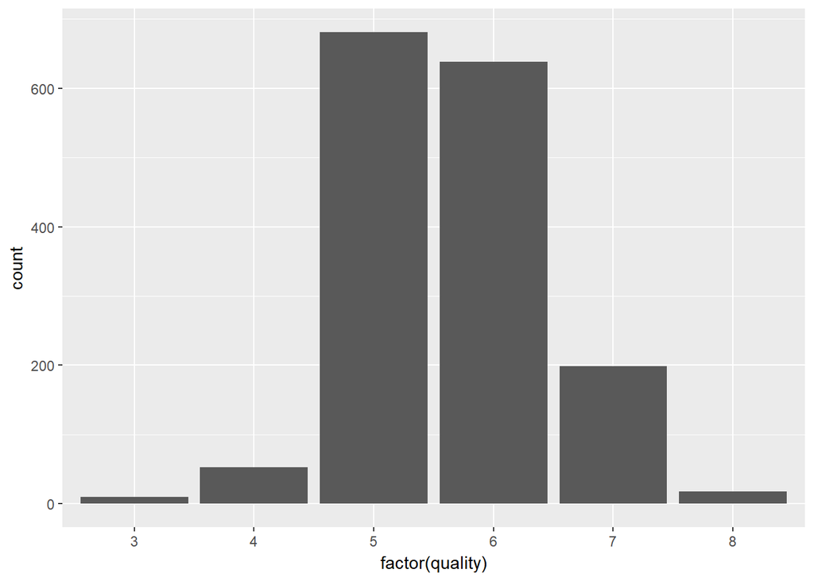

### Given dataset has majority of the data recorded for the wine whose quality values are with 5 and 6.

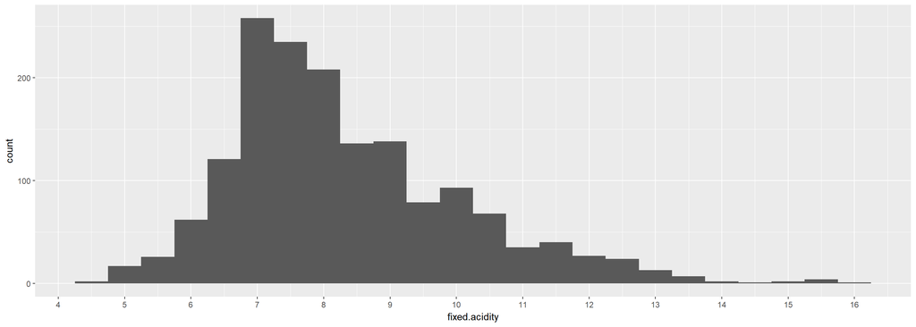

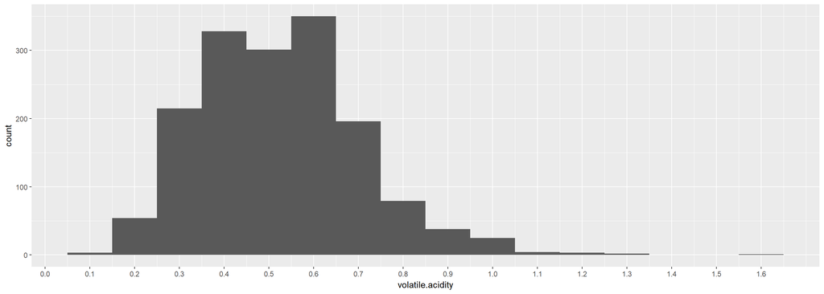

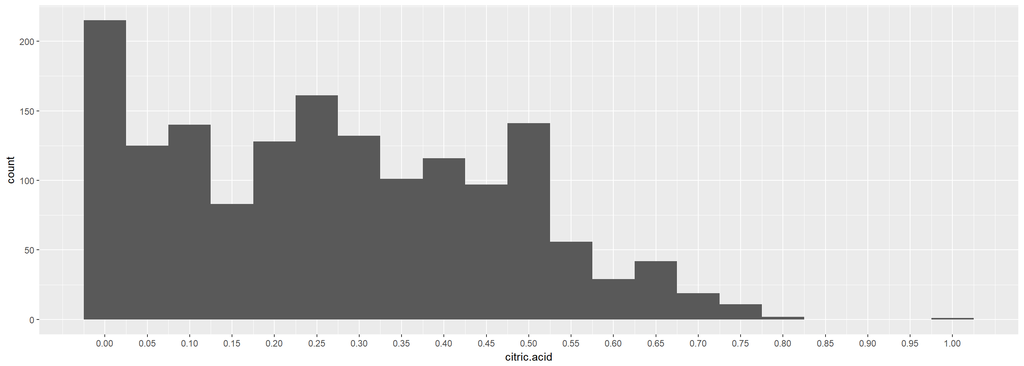

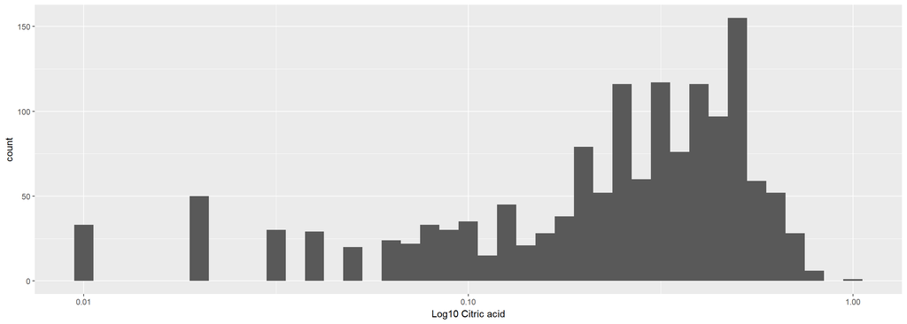

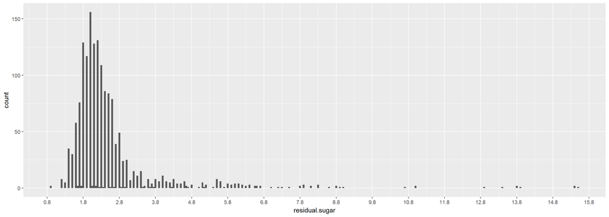

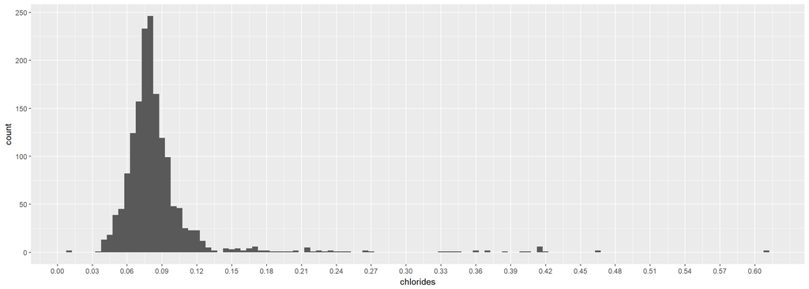

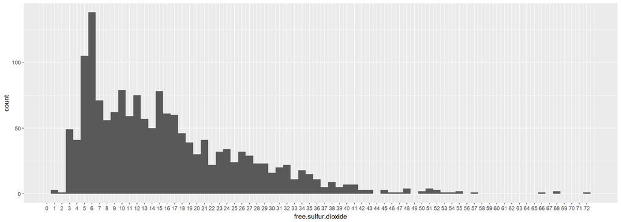

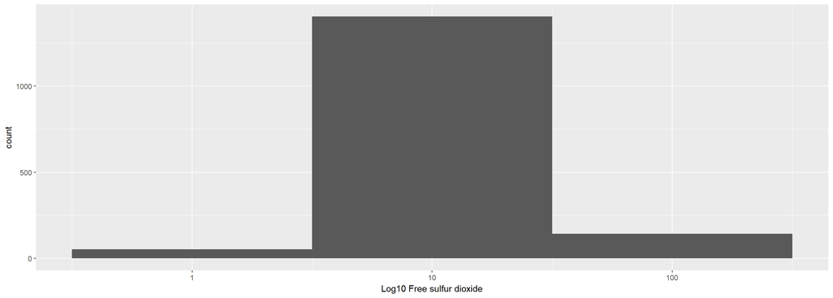

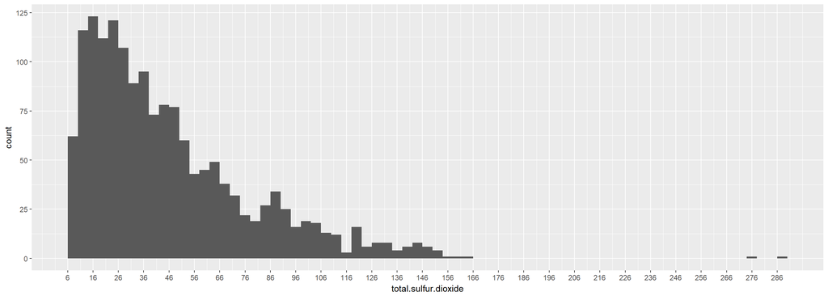

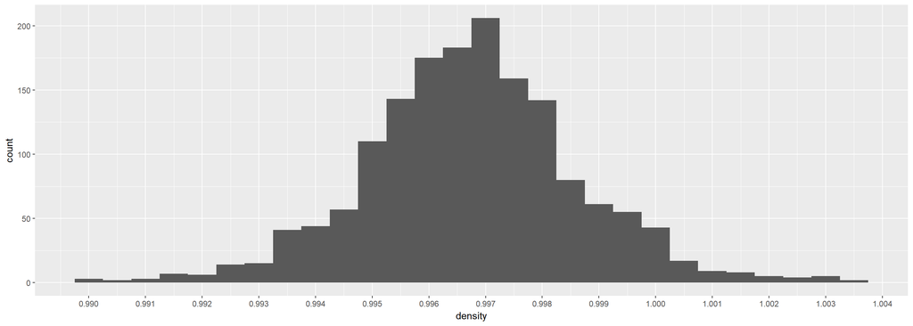

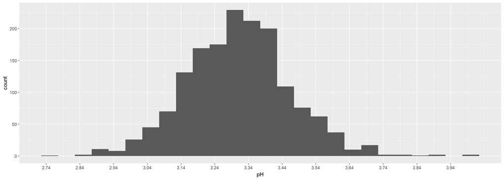

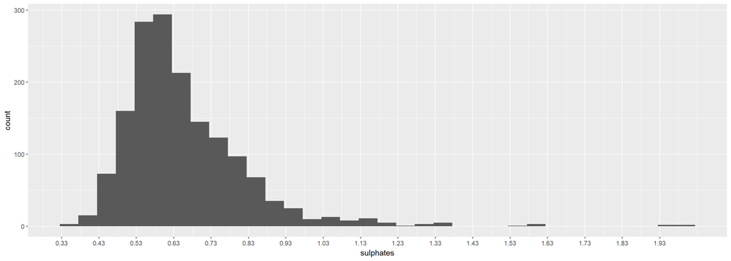

[2 more figures not shown]

# Univariate observation of the plots

# Univariate Analysis

### What is the structure of your dataset?

The given Red wine dataset had around 1599 observations with 13 features.

### What is/are the main feature(s) of interest in your dataset?

Main feature of interest in this dataset is the quality of Red wine.

### What other features in the dataset do you think will help support your investigation into your feature(s) of interest?

Other features like alcohol, acidity,PH will help us to understand how they influence the quality of the wine.

### Did you create any new variables from existing variables in the dataset?

Created a categorical variable - quality_Category based on the value of the quality.This variable has been created to study how the quality is affected by the other parameters like acidity,pH,Density, alcohol etc.

We also added another category variable based on alcohol value. That field is alcohol_Category

### Of the features you investigated, were there any unusual distributions?

# Bivariate Plots Section

In this section , we will create the scatter plots using quality_category and all other variables. Based on this scatter plot, we will be able to determine which variables are influencing the wine quality.

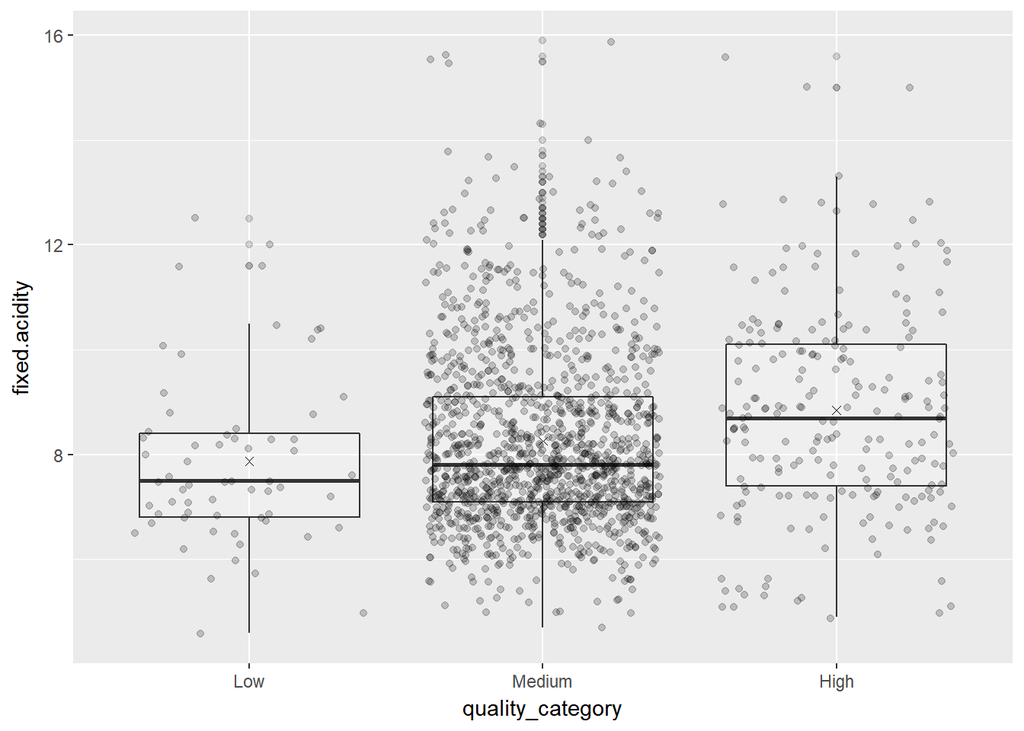

```
## wineframe$quality_category: Low
##    Min. 1st Qu.  Median    Mean 3rd Qu.    Max.
##   4.600   6.800   7.500   7.871   8.400  12.500
## --------------------------------------------------------
## wineframe$quality_category: Medium
##    Min. 1st Qu.  Median    Mean 3rd Qu.    Max.
##   4.700   7.100   7.800   8.254   9.100  15.900
## --------------------------------------------------------
## wineframe$quality_category: High
##    Min. 1st Qu.  Median    Mean 3rd Qu.    Max.
##   4.900   7.400   8.700   8.847  10.100  15.600
```

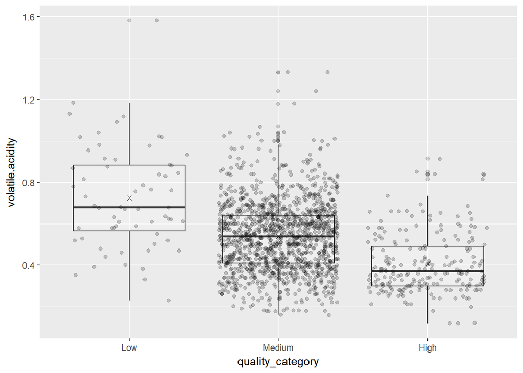

[output not shown]

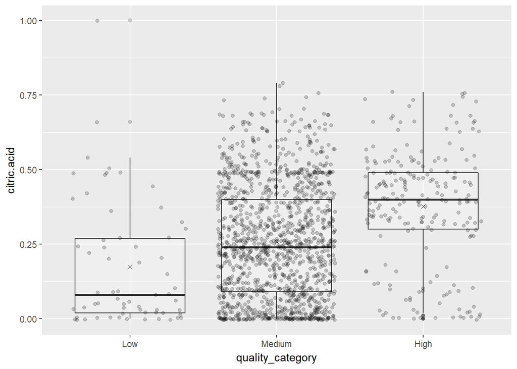

```
## wineframe$quality_category: Low
##    Min. 1st Qu.  Median    Mean 3rd Qu.    Max.
##  0.0000  0.0200  0.0800  0.1737  0.2700  1.0000
## --------------------------------------------------------
## wineframe$quality_category: Medium
##    Min. 1st Qu.  Median    Mean 3rd Qu.    Max.
##  0.0000  0.0900  0.2400  0.2583  0.4000  0.7900
## --------------------------------------------------------
## wineframe$quality_category: High
##    Min. 1st Qu.  Median    Mean 3rd Qu.    Max.
##  0.0000  0.3000  0.4000  0.3765  0.4900  0.7600
```

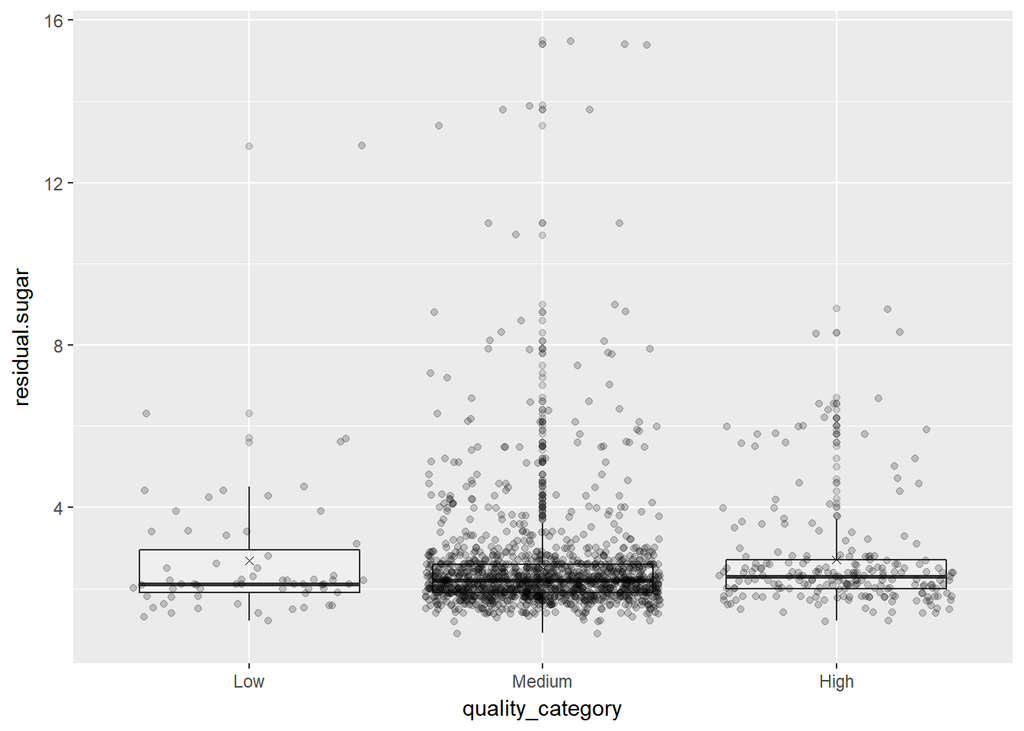

```
## wineframe$quality_category: Low
##    Min. 1st Qu.  Median    Mean 3rd Qu.    Max.
##   1.200   1.900   2.100   2.685   2.950  12.900
## --------------------------------------------------------
## wineframe$quality_category: Medium
##    Min. 1st Qu.  Median    Mean 3rd Qu.    Max.
##   0.900   1.900   2.200   2.504   2.600  15.500
## --------------------------------------------------------
## wineframe$quality_category: High
##    Min. 1st Qu.  Median    Mean 3rd Qu.    Max.
##   1.200   2.000   2.300   2.709   2.700   8.900
```

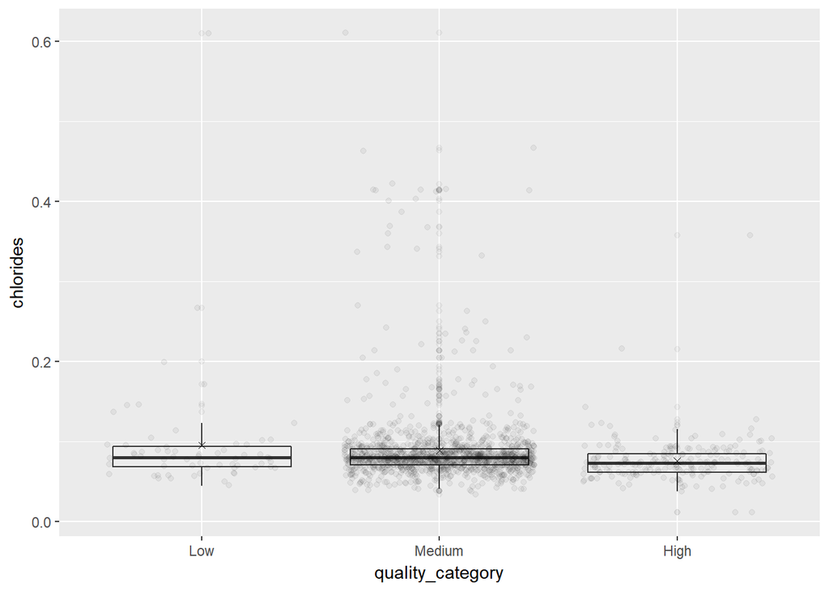

```
## wineframe$quality_category: Low
##    Min. 1st Qu.  Median    Mean 3rd Qu.    Max.
## 0.04500 0.06850 0.08000 0.09573 0.09450 0.61000
## --------------------------------------------------------
## wineframe$quality_category: Medium
##    Min. 1st Qu.  Median    Mean 3rd Qu.    Max.
## 0.03400 0.07100 0.08000 0.08897 0.09100 0.61100
## --------------------------------------------------------
## wineframe$quality_category: High
##    Min. 1st Qu.  Median    Mean 3rd Qu.    Max.
## 0.01200 0.06200 0.07300 0.07591 0.08500 0.35800
```

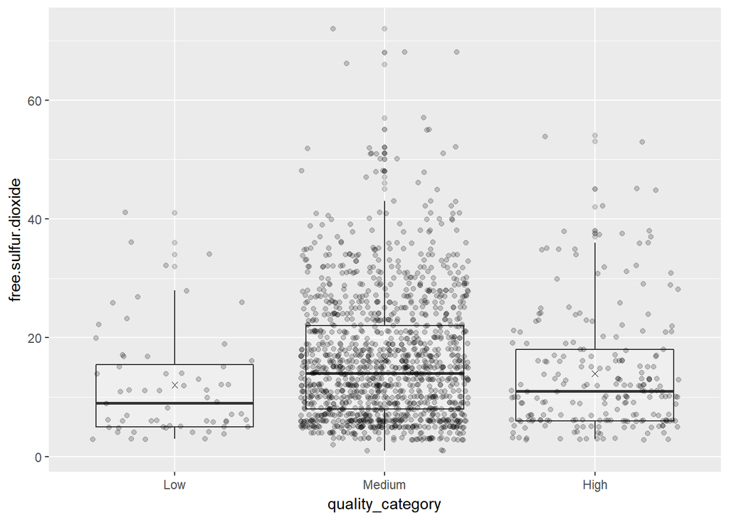

```
## wineframe$quality_category: Low
##    Min. 1st Qu.  Median    Mean 3rd Qu.    Max.
##    3.00    5.00    9.00   12.06   15.50   41.00
## --------------------------------------------------------
## wineframe$quality_category: Medium
##    Min. 1st Qu.  Median    Mean 3rd Qu.    Max.
##    1.00    8.00   14.00   16.37   22.00   72.00
## --------------------------------------------------------
## wineframe$quality_category: High
##    Min. 1st Qu.  Median    Mean 3rd Qu.    Max.
##    3.00    6.00   11.00   13.98   18.00   54.00
```

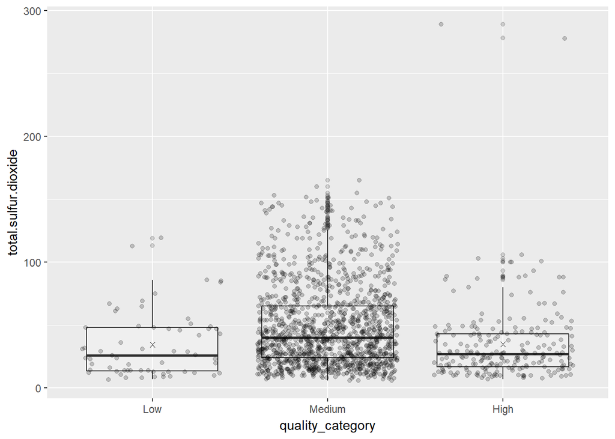

```
## wineframe$quality_category: Low
##    Min. 1st Qu.  Median    Mean 3rd Qu.    Max.
##    7.00   13.50   26.00   34.44   48.00  119.00
## --------------------------------------------------------
## wineframe$quality_category: Medium
##    Min. 1st Qu.  Median    Mean 3rd Qu.    Max.
##    6.00   24.00   40.00   48.95   65.00  165.00
## --------------------------------------------------------
## wineframe$quality_category: High
##    Min. 1st Qu.  Median    Mean 3rd Qu.    Max.
##    7.00   17.00   27.00   34.89   43.00  289.00
```

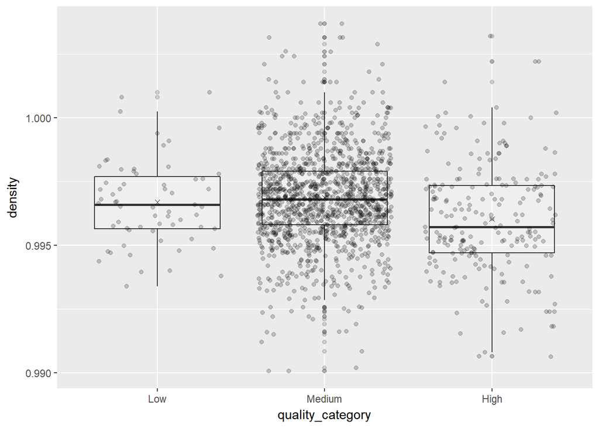

```
## wineframe$quality_category: Low
##    Min. 1st Qu.  Median    Mean 3rd Qu.    Max.
##  0.9934  0.9957  0.9966  0.9967  0.9977  1.0010
## --------------------------------------------------------
## wineframe$quality_category: Medium
##    Min. 1st Qu.  Median    Mean 3rd Qu.    Max.
##  0.9901  0.9958  0.9968  0.9969  0.9979  1.0037
## --------------------------------------------------------
## wineframe$quality_category: High
##    Min. 1st Qu.  Median    Mean 3rd Qu.    Max.
##  0.9906  0.9947  0.9957  0.9960  0.9973  1.0032
```

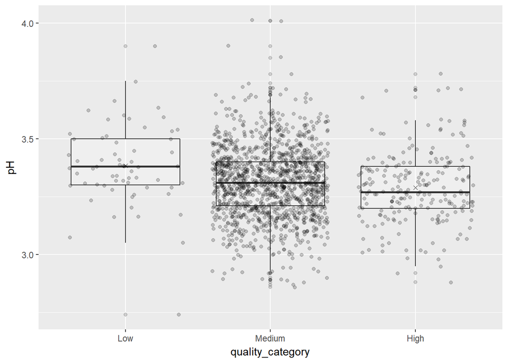

```
## wineframe$quality_category: Low
##    Min. 1st Qu.  Median    Mean 3rd Qu.    Max.
##   2.740   3.300   3.380   3.384   3.500   3.900
## --------------------------------------------------------
## wineframe$quality_category: Medium
##    Min. 1st Qu.  Median    Mean 3rd Qu.    Max.
##   2.860   3.210   3.310   3.311   3.400   4.010
## --------------------------------------------------------
## wineframe$quality_category: High
##    Min. 1st Qu.  Median    Mean 3rd Qu.    Max.
##   2.880   3.200   3.270   3.289   3.380   3.780
```

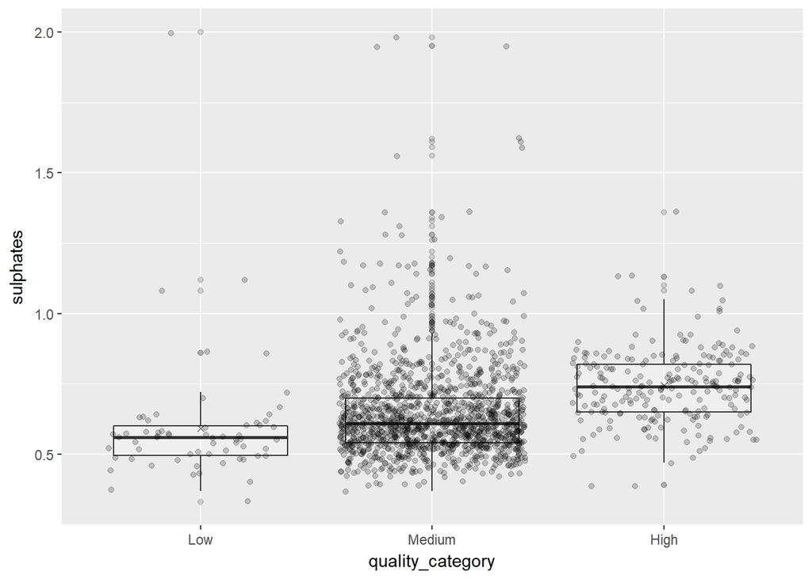

```
## wineframe$quality_category: Low
##    Min. 1st Qu.  Median    Mean 3rd Qu.    Max.
##  0.3300  0.4950  0.5600  0.5922  0.6000  2.0000
## --------------------------------------------------------
## wineframe$quality_category: Medium
##    Min. 1st Qu.  Median    Mean 3rd Qu.    Max.
##  0.3700  0.5400  0.6100  0.6473  0.7000  1.9800
## --------------------------------------------------------
## wineframe$quality_category: High
##    Min. 1st Qu.  Median    Mean 3rd Qu.    Max.
##  0.3900  0.6500  0.7400  0.7435  0.8200  1.3600
```

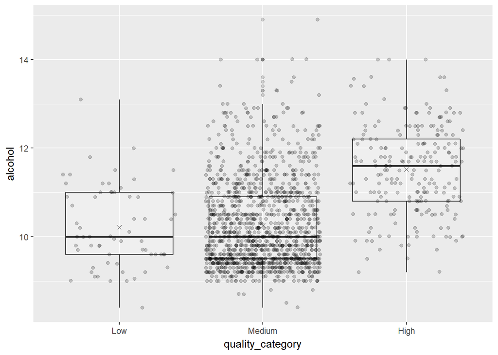

```
## wineframe$quality_category: Low
##    Min. 1st Qu.  Median    Mean 3rd Qu.    Max.
##    8.40    9.60   10.00   10.22   11.00   13.10
## --------------------------------------------------------
## wineframe$quality_category: Medium
##    Min. 1st Qu.  Median    Mean 3rd Qu.    Max.
##    8.40    9.50   10.00   10.25   10.90   14.90
## --------------------------------------------------------
## wineframe$quality_category: High
##    Min. 1st Qu.  Median    Mean 3rd Qu.    Max.
##    9.20   10.80   11.60   11.52   12.20   14.00
```

```
##
##  Pearson's product-moment correlation
##
## data:  quality_median$med_fixacid and quality_median$quality
## t = 2.9894, df = 4, p-value = 0.04036
## alternative hypothesis: true correlation is not equal to 0
## 95 percent confidence interval:
##  0.06017288 0.98099842
## sample estimates:
##      cor
## 0.831146
```

```
##
##  Pearson's product-moment correlation
##
## data:  quality_median$med_volacid and quality_median$quality
## t = -8.5455, df = 4, p-value = 0.001029
## alternative hypothesis: true correlation is not equal to 0
## 95 percent confidence interval:
##  -0.9972304 -0.7727990
## sample estimates:
##        cor
## -0.9736885
```

```
##
##  Pearson's product-moment correlation
##
## data:  quality_median$med_citacid and quality_median$quality
## t = 10.747, df = 4, p-value = 0.0004249
## alternative hypothesis: true correlation is not equal to 0
## 95 percent confidence interval:
##  0.848739 0.998231
## sample estimates:
##       cor
## 0.9831221
```

```
##
##  Pearson's product-moment correlation
##
## data:  quality_median$med_resug and quality_median$quality
## t = 0.85424, df = 4, p-value = 0.4411
## alternative hypothesis: true correlation is not equal to 0
## 95 percent confidence interval:
##  -0.6147294  0.9132366
## sample estimates:
##       cor
## 0.3927922
```

```
##
##  Pearson's product-moment correlation
##
## data:  quality_median$med_chlor and quality_median$quality
## t = -5.7391, df = 4, p-value = 0.004567
## alternative hypothesis: true correlation is not equal to 0
## 95 percent confidence interval:
##  -0.9940581 -0.5681418
## sample estimates:
##        cor
## -0.9443024
```

```
##
##  Pearson's product-moment correlation
##
## data:  quality_median$med_freesulf and quality_median$quality
## t = 0.1985, df = 4, p-value = 0.8523
## alternative hypothesis: true correlation is not equal to 0
## 95 percent confidence interval:
##  -0.7749078  0.8427749
## sample estimates:
##        cor
## 0.09876583
```

```
##
##  Pearson's product-moment correlation
##
## data:  quality_median$med_totsulf and quality_median$quality
## t = 0.22628, df = 4, p-value = 0.8321
## alternative hypothesis: true correlation is not equal to 0
## 95 percent confidence interval:
##  -0.7693307  0.8467301
## sample estimates:
##       cor
## 0.1124227
```

```
##
##  Pearson's product-moment correlation
##
## data:  quality_median$med_density and quality_median$quality
## t = -4.3941, df = 4, p-value = 0.01175
## alternative hypothesis: true correlation is not equal to 0
## 95 percent confidence interval:
##  -0.9902625 -0.3772496
## sample estimates:
##        cor
## -0.9101564
```

```
##
##  Pearson's product-moment correlation
##
## data:  quality_median$med_ph and quality_median$quality
## t = -6.275, df = 4, p-value = 0.003293
## alternative hypothesis: true correlation is not equal to 0
## 95 percent confidence interval:
##  -0.9949815 -0.6227351
## sample estimates:
##        cor
## -0.9527754
```

```
##
##  Pearson's product-moment correlation
##
## data:  quality_median$med_sulphates and quality_median$quality
## t = 6.4728, df = 4, p-value = 0.002935
## alternative hypothesis: true correlation is not equal to 0
## 95 percent confidence interval:
##  0.6405303 0.9952694
## sample estimates:
##       cor
## 0.9554305
```

```
##
##  Pearson's product-moment correlation
##
## data:  quality_median$med_alcohol and quality_median$quality
## t = 3.9481, df = 4, p-value = 0.01685
## alternative hypothesis: true correlation is not equal to 0
## 95 percent confidence interval:
##  0.2916591 0.9882025
## sample estimates:
##       cor
## 0.8920685
```

# Based on above box plots as well as correlation summary -

1. Acidic property (citric acid, fixed acidity, volatile acidity) is influencing the wine
2. sulphates content is influencing the wine quality
3. chlorides,density is also affecting the wine - lower these values better the quality of wine.
4. alcohol content is influencing the wine.

Let us try to find out the variables influencing the density, fixed acidity and volatile acidity. Also we try to understand how fixed acidity and volatile acidity is related to pH Value.

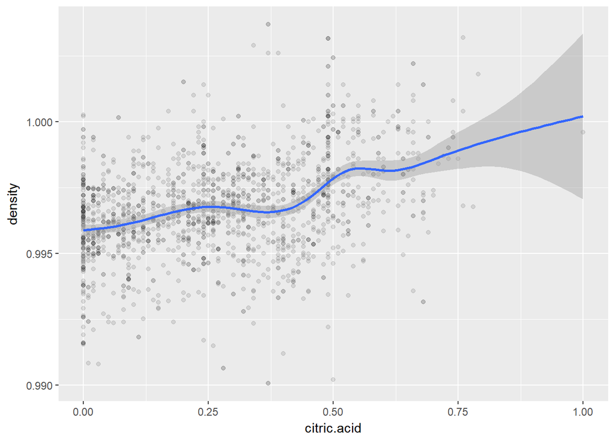

```
##
##  Pearson's product-moment correlation
##
## data:  wineframe$citric.acid and wineframe$density
## t = 15.665, df = 1597, p-value < 2.2e-16
## alternative hypothesis: true correlation is not equal to 0
## 95 percent confidence interval:
##  0.3216809 0.4066925
## sample estimates:
##       cor
## 0.3649472
```

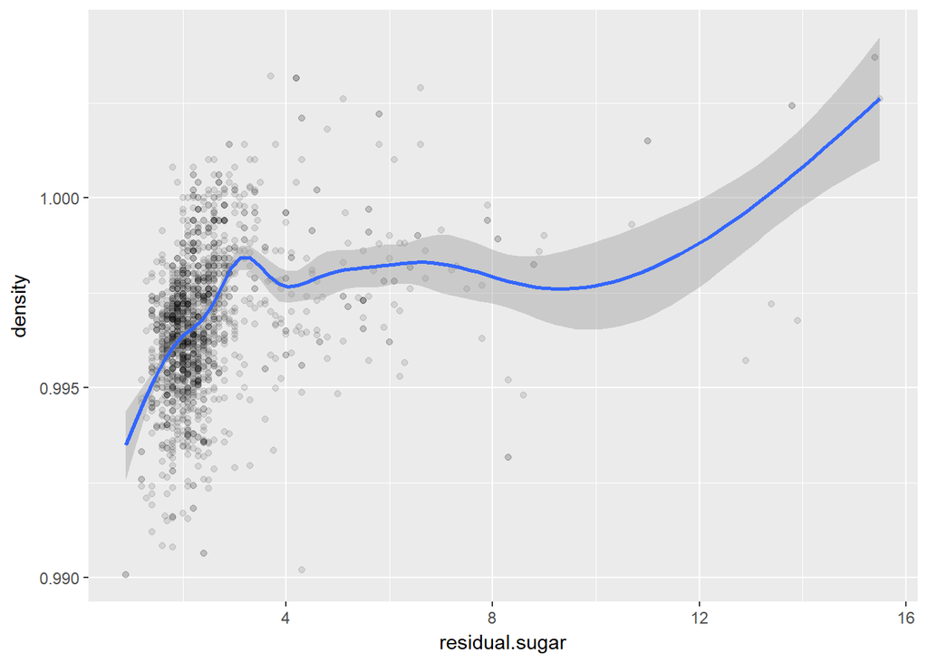

```
##
##  Pearson's product-moment correlation
##
## data:  wineframe$residual.sugar and wineframe$density
## t = 15.189, df = 1597, p-value < 2.2e-16
## alternative hypothesis: true correlation is not equal to 0
## 95 percent confidence interval:
##  0.3116908 0.3973835
## sample estimates:
##       cor
## 0.3552834
```

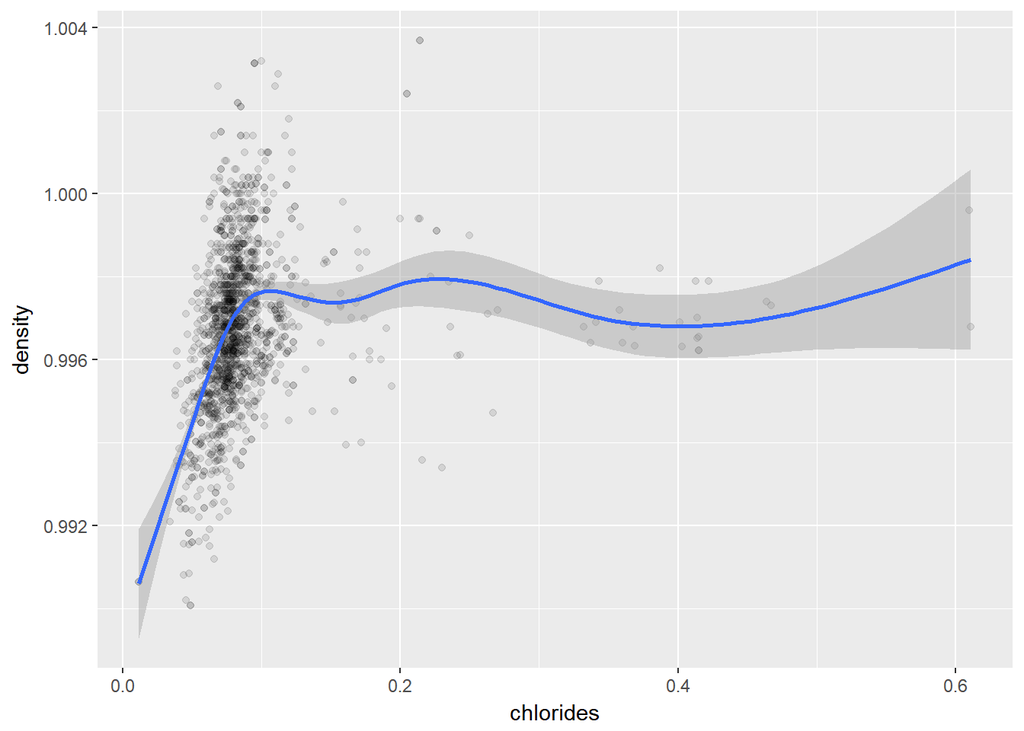

```
##
##  Pearson's product-moment correlation
##
## data:  wineframe$chlorides and wineframe$density
## t = 8.1842, df = 1597, p-value = 5.541e-16
## alternative hypothesis: true correlation is not equal to 0
## 95 percent confidence interval:
##  0.1531171 0.2472220
## sample estimates:
##       cor
## 0.2006323
```

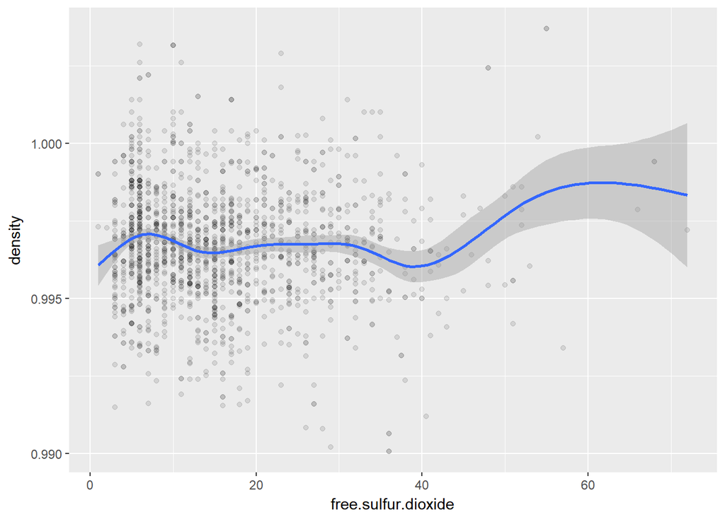

```
##
##  Pearson's product-moment correlation
##
## data:  wineframe$free.sulfur.dioxide and wineframe$density
## t = -0.87722, df = 1597, p-value = 0.3805
## alternative hypothesis: true correlation is not equal to 0
## 95 percent confidence interval:
##  -0.07089071  0.02710447
## sample estimates:
##         cor
## -0.02194583
```